# **Analysis of Popular and Unpopular Songs**

### By: Robert Liddell

### 2017

## 1. Description

This document is an outline of my analysis of popular and unpopular spotify music using Python. Music features were analysed to determine which characteristics lend themselves to popular music

1. Identify what makes a song popular
2. Determine if there are unpopular songs which would actually fit in the popular group
3. Can we categorize popular songs?

### Features

- **artist**:Name of the Artist.
- **song**: Name of the Track.
- **genre**: Genre of the track.
- **duration_ms**: Duration of the track in milliseconds.
- **explicit**: The lyrics or content of a song or a music video contain one or more of the criteria which could be considered offensive or unsuitable for children.
- **year**: Release Year of the track.
- **popularity**: Spotify popularity ranges from 0 to 100 and is based on the playback rate, as well as the total and recent amount of listens
- **danceability**: Danceability describes how suitable a track is for dancing based on a combination of musical elements including tempo, rhythm stability, beat strength, and overall regularity. A value of 0.0 is least danceable and 1.0 is most danceable.
- **energy**: Energy is a measure from 0.0 to 1.0 and represents a perceptual measure of intensity and activity.
- **key**: The key the track is in. Integers map to pitches using standard Pitch Class notation. E.g. 0 = C, 1 = C♯/D♭, 2 = D, and so on. If no key was detected, the value is -1.
- **mode**: Mode indicates the modality (major or minor) of a track, the type of scale from which its melodic content is derived. Major is represented by 1 and minor is 0.
- **loudness**: The overall loudness of a track in decibels (dB). Loudness values are averaged across the entire track and are useful for comparing relative loudness of tracks. Loudness is the quality of a sound that is the primary psychological correlate of physical strength (amplitude). Values typically range between -60 and 0 db.
- **speechiness**: Speechiness detects the presence of spoken words in a track. The more exclusively speech-like the recording (e.g. talk show, audio book, poetry), the closer to 1.0 the attribute value. Values above 0.66 describe tracks that are probably made entirely of spoken words. Values between 0.33 and 0.66 describe tracks that may contain both music and speech, either in sections or layered, including such cases as rap music. Values below 0.33 most likely represent music and other non-speech-like tracks.
- **acousticness**: A confidence measure from 0.0 to 1.0 of whether the track is acoustic. 1.0 represents high confidence the track is acoustic.
- **instrumentalness**: Predicts whether a track contains no vocals. "Ooh" and "aah" sounds are treated as instrumental in this context. Rap or spoken word tracks are clearly "vocal". The closer the instrumentalness value is to 1.0, the greater likelihood the track contains no vocal content. Values above 0.5 are intended to represent instrumental tracks, but confidence is higher as the value approaches 1.0.
- **liveness**: Detects the presence of an audience in the recording. Higher liveness values represent an increased probability that the track was performed live. A value above 0.8 provides strong likelihood that the track is live.
- **valence**: A measure from 0.0 to 1.0 describing the musical positiveness conveyed by a track. Tracks with high valence sound more positive (e.g. happy, cheerful, euphoric), while tracks with low valence sound more negative (e.g. sad, depressed, angry).
- **tempo**: The overall estimated tempo of a track in beats per minute (BPM). In musical terminology, tempo is the speed or pace of a given piece and derives directly from the average beat duration.

### Hypotheses

1. Positive music is more likely to be popular.
2. High energy music is more likely to be popular.
3. High danceability music is more likely to be popular.

## 2. Data Set Summary

Contains 12115 total different songs with 20 different features

| id | track_artist | track_name | duration_ms | explicit | year | popularity | danceability | energy | key | loudness | mode | speechiness | acousticness | ... |
| --- | --- | --- | --- | --- | --- | --- | --- | --- | --- | --- | --- | --- | --- | --- |
| 0 | Britney Spears | Oops!...I Did It Again | 211160 | 0 | 2000.0 | 77 | 0.751 | 0.834 | 1 | -5.444 | 0 | 0.0437 | 0.3000 | ... |
| 1 | blink-182 | All The Small Things | 167066 | 0 | 1999.0 | 79 | 0.434 | 0.897 | 0 | -4.918 | 1 | 0.0488 | 0.0103 | ... |
| 2 | Faith Hill | Breathe | 250546 | 0 | 1999.0 | 66 | 0.529 | 0.496 | 7 | -9.007 | 1 | 0.0290 | 0.1730 | ... |
| 3 | Bon Jovi | It's My Life | 224493 | 0 | 2000.0 | 78 | 0.551 | 0.913 | 0 | -4.063 | 0 | 0.0466 | 0.0263 | ... |
| 4 | *NSYNC | Bye Bye Bye | 200560 | 0 | 2000.0 | 65 | 0.614 | 0.928 | 8 | -4.806 | 0 | 0.0516 | 0.0408 | ... |
| ... | ... | ... | ... | ... | ... | ... | ... | ... | ... | ... | ... | ... | ... | ... |

When analysing this data genre was coded in two ways. The first simplified genre to one of 23 main genres. The second used the full genre type of which there were 582 different ones.

23 main musical genres: pop, hip-hop, rock, r&b, soul, reggae, country, funk, folk, jazz, rap, other, unknown, disco, classical, electronic, latin, blues, ska, traditional, world, indie, metal

Data set contains 12115 different songs, 13% are popular and 87% unpopular and of the 2775 different artists, 25.62% have at least one popular songs.

## 3 Feature Distribution

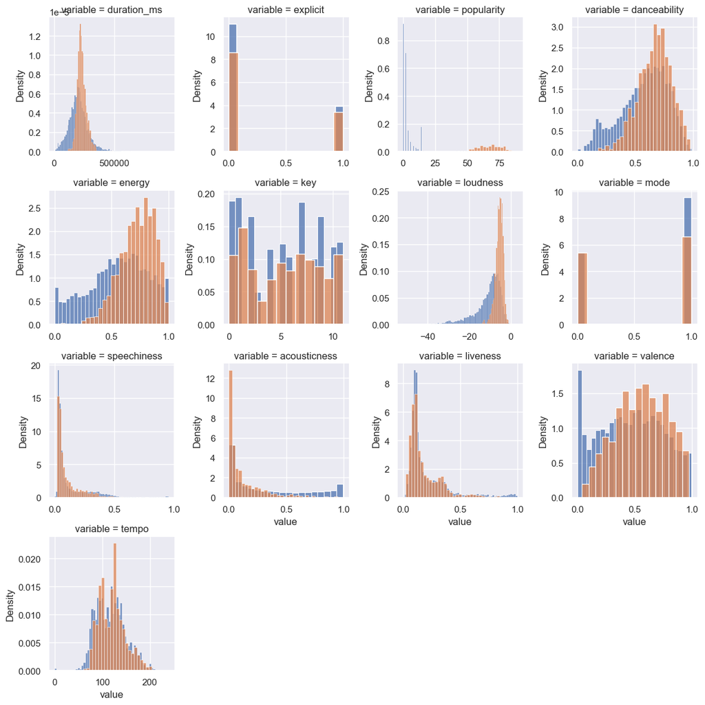

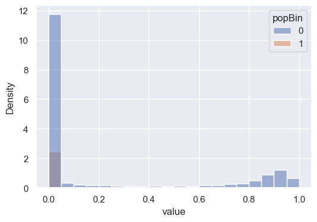

### 3.1 Notes on each variables:

1. Duartion: Popular songs have a tighter distribution
2. Danceability: Popular songs tend to have greater danceability
3. Energy: Popular songs tend to have higher energy
4. Loudness: Popular songs tend to be louder
5. Acousticness: Popular songs tend to not be acoustic but instead include more syth and electric instruments
6. Valence (positivity): Popular songs tend to be more chearful
7. Instrumental: Popular songs tend not to be purely instrumental

## 4. Comparing Features

### 4.1 Logistic Regression

| Feature | OddsRatio |
| --- | --- |
| danceability | 7.732207 |
| energy | 0.334925 |
| loudness | 1.606272 |
| liveness | 0.393282 |

### 4.2 Group mean Comparisons by t-test

| Feature: | Means:pop. vs. unpop. | %Diff | TStat | P-Val |
| --- | --- | --- | --- | --- |
| Duration (ms) | 229931.88 vs. 206923.66 | 10 | 15.98 | 0.0 |
| Explicit | 0.29 vs. 0.26 | 10 | 1.88 | 0.0644 |
| Danceability | 0.67 vs. 0.57 | 16 | 22.62 | 0.0 |
| energy | 0.72 vs. 0.56 | 24 | 36.35 | 0.0 |
| Loudness | -5.5 vs. -11.21 | -68 | 69.03 | 0.0 |
| Mode | 0.55 vs. 0.64 | 15 | -6.67 | 0.0 |
| Speechiness | 0.11 vs. 0.14 | 24 | -10.28 | 0.0 |
| Acousticness | 0.13 vs. 0.35 | 91 | -39.69 | 0.0 |
| Instrumentalness | 0.01 vs 0.23 | 183 | -51.95 | 0.0 |
| Liveness | 0.18 vs. 0.21 | 15 | -7.72 | 0.0 |
| Valence | 0.56 vs. 0.47 | 17 | 14.22 | 0.0 |
| Tempo | 120.41 vs. 117.78 | 2 | 3.49 | 0.0005 |

For the above tests we used a permutation test as the allows for the test to be robust against different sample distributions.

The only metric above which we lack sufficient evidence to reject the null hypothesis (Ho: That popular and unpopular music is similar) is explicit language. Otherwise all other groups we tested are significantly different. However many of these groups could be argued to have differences which are immaterial.

Of these variables we can highlight **loudness, acousticness, instrumentalness, energy,** and **speechiness** as having significant and sizable differences between the popular and unpopular groups.

## 5. Conclusions with Respect to Hypotheses:

1. Positive music is more likely to be popular.

While having statistical significance and being higher for popular music the percent difference was smaller at 17%

2. High energy music is more likely to be popular.

Popular music had an energy level 24% higher

3. High danceability music is more likely to be popular.

Popular music was 16% more dancable

## 6. Classification

### 6.1 Feature Correlations

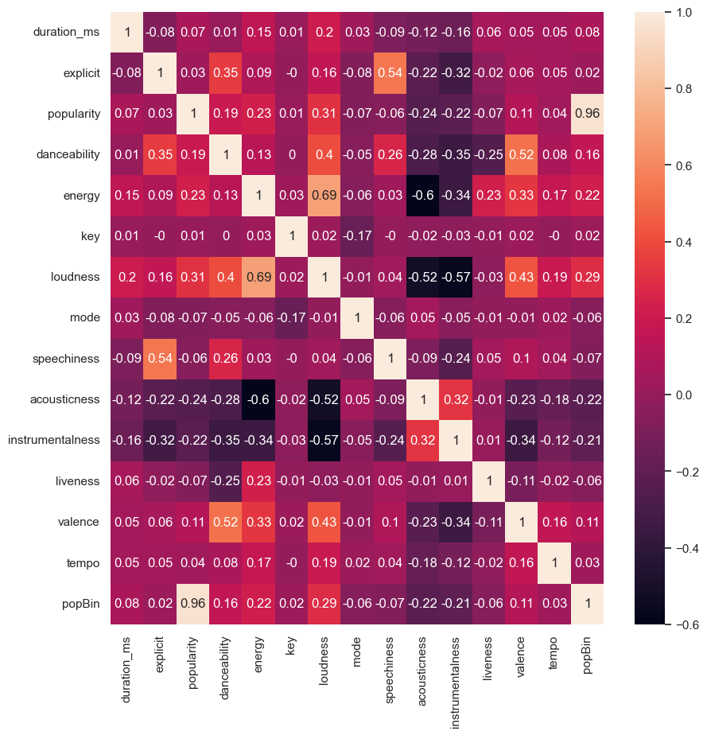

#### Correlation Notes:

1. Popularity and the popBin have high correlation as expected (0.96)
2. Loudness is correlated with energy (0.69) and negatively correlated with instrumentalness (-0.57)
3. Explicity content is correlated with high speachiness in a song (0.54)
4. Valence and Danceability have a correlation of (0.52)
5. Acousticness is negatively correlated with energy (-0.6) and loudness(-0.52)

### 6.2 Decision Tree

This decision tree used the simpliefied genres, but coded them as a fraction of the whole. Ex. Being pop and hip-hop makes a song 50% each category.

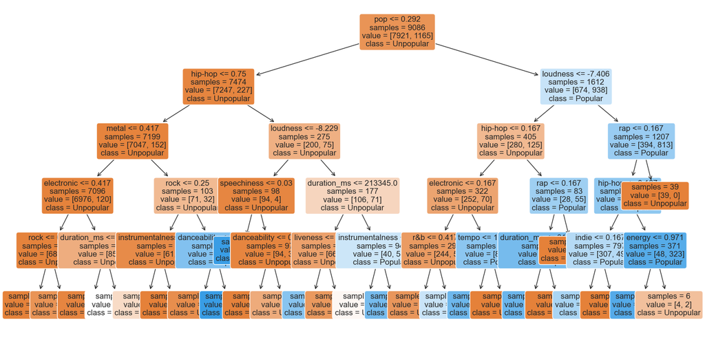

#### 6.2.1 Training Curve

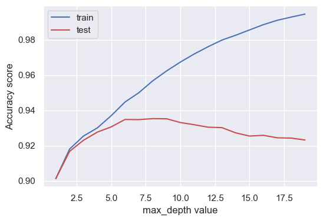

#### 6.2.2 Confusion Matrix Results:

|  | Predicted: Popular | Predicted: Unpopular |
| --- | --- | --- |
| **Actually Popular** | 293 | 79 |
| **Actually Unpopular** | 79 | 2562 |